# Genomic tools for fisheries analysis in R

Nick Jeffery; Brendan Wringe; Ryan Stanley

February 21, 2018

## Population Clustering

#### First we are going to run our genepop file through some basic clustering methods to look at poplation structure.

#### Load the libraries first.

```r
library(knitr)
library(devtools)
library(genepopedit)
library(pcadapt)
library(diveRsity)
library(randomForest)
library(ggplot2)
library(adegenet)
library(qvalue)
```

Load the genepop file into the workspace. ncode=3 in the options here because we have 3 numbers coding for one alleles in the document.

```r
crabgen<-read.genepop(file = "Crab_Genepop_EnvOutliers.gen",ncode = 3,quiet = F)
```

```
 Converting data from a Genepop .gen file to a genind object...


File description:  Green Crab SNPS

...done.
```

Show information about the data we have entered

```r
crabgen
```

```
/// GENIND OBJECT /////////

 // 241 individuals; 45 loci; 90 alleles; size: 125.2 Kb

 // Basic content
   @tab:  241 x 90 matrix of allele counts
   @loc.n.all: number of alleles per locus (range: 2-2)
   @loc.fac: locus factor for the 90 columns of @tab
   @all.names: list of allele names for each locus
   @ploidy: ploidy of each individual  (range: 2-2)
   @type:  codom
   @call: read.genepop(file = "Crab_Genepop_EnvOutliers.gen", ncode = 3,
    quiet = F)

 // Optional content
   @pop: population of each individual (group size range: 21-22)
```

##### Questions 1:

1. How many individuals are there?
2. How many loci?
3. How would you look at the genotype of an individuals

Scale the data to prepare for PCA

```r
crabpcadat<-scaleGen(crabgen,NA.method="zero")
```

##### Questions 2:

4. Why do we scale the data?

Do a PCA

```r
CrabPCA<-dudi.pca(crabpcadat,scannf = F,nf = 3)
```

Plot the PCA

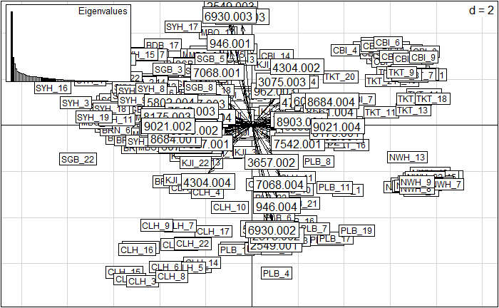

```r
scatter(CrabPCA)
```

Doesn’t look so good

Let’s plot it a different way!

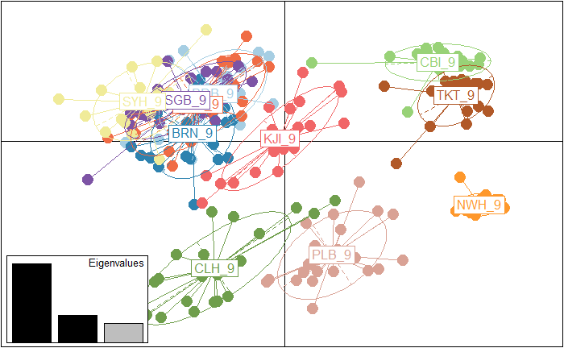

```r
s.class(CrabPCA$li,pop(crabgen),col=funky(11),cstar = 1,cpoint = 3,grid=FALSE)
add.scatter.eig(CrabPCA$eig[1:3],3,1,2)
```

Show the proportion of the total variance the first PC accounts for

```r
CrabPCA$eig[1]/sum(CrabPCA$eig)
```

```
[1] 0.2443346
```

Show the proportion of the total variance the second PC accounts for

```r
CrabPCA$eig[2]/sum(CrabPCA$eig)
```

```
[1] 0.08463758
```

##### Questions 3:

5. If you were to group the populations into two groups, what would those be?
6. How would you go about returning the PC values for indivuduals?

### Now we’ll try the adegenet snapclust function. First we give it a range of values for K to test.

#### Note: The value with the lowest AIC is best.

Get AIC

```r
a.aic<-snapclust.choose.k(max = 11,crabgen)
```

Show the AICs

```r
a.aic
```

```
       1        2        3        4        5        6        7        8        9       10       11
18062.82 14781.40 14234.53 13935.68 13720.35 13557.04 13442.60 13382.49 13329.08 13328.36 13301.73
```

Plot them

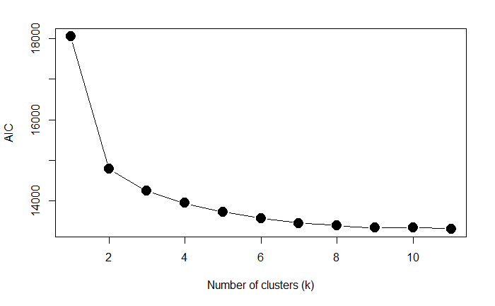

```r
plot(1:11, a.aic, xlab = "Number of clusters (k)",
     ylab = "AIC", type = "b", pch = 20, cex = 3)
```

##### Questions 4:

7. What do these AIC values imply to you (Are there likely to be statistically signficant differences among them)?
8. Is this likely the best tool to use to separate these populations?

### Because we know from other methods that green crab are best described by K=2, we’ll just go with that.

```r
bestK<-snapclust(crabgen,k = 2,pop.ini = "kmeans")
```

This will make a really big data frame showing the proportion assignment of each individual into each of the two groupings

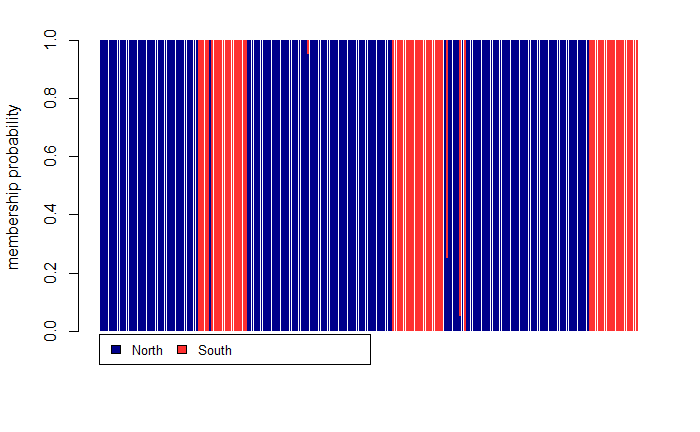

```r
compoplot(bestK, col=c("darkblue","firebrick1"),txt.leg=c("North","South"))
```

# IT’S TIME FOR GENEPOPEDIT!!!!!

One of the useful tools in genepopedit is that you can easily check the metadata of a genepop file (Populations, Individual names, loci names, allele values, and counts of individuals in populations)

Check what populations are in the genepop file you have been given

```r
genepop_detective(genepop = "crabGP_Fixed.txt", variable = "Pops")
```

```
 [1] "BDB" "BRN" "CBI" "CLH" "KJI" "MBO" "NWH" "PLB" "SGB" "SYH" "TKT"
```

##### Questions 4:

9. Show the allele names in the supplied genepop file
10. Show the number of individuals in each population

## Geneopopedit can also be used to modify genepopfiles (e.g. subset individuals, populations, loci, etc.)

Separate the groups we have now into “North” and “South” groupings

```r
subset_genepop_aggregate(genepop = "crabGP_Fixed.txt", agpopframe = data.frame(old = c("BDB", "BRN", "CBI", "CLH", "KJI", "MBO", "NWH", "PLB", "SGB", "SYH", "TKT"), new = c("NTH", "NTH","NTH","NTH","NTH","NTH","STH","STH","STH","STH","STH")), path = "crabGP_Fixed_North_South.txt")
```

This has separated it into the two populations and aggregated them together - unfortunately, it hasn’t renamed the populations - take a look!

Show populations now

```r
genepop_detective(genepop = "crabGP_Fixed_North_South.txt", variable = "Pops")
```

```
 [1] "BDB" "BRN" "CBI" "CLH" "KJI" "MBO" "NWH" "PLB" "SGB" "SYH" "TKT"
```

RENAME THEM! - hint, just reuse the same data frame you used for aggregating

```r
subset_genepop_rename(genepop = "crabGP_Fixed_North_South.txt", nameframe = data.frame(old = c("BDB", "BRN", "CBI", "CLH", "KJI", "MBO", "NWH", "PLB", "SGB", "SYH", "TKT"), new = c("NTH", "NTH","NTH","NTH","NTH","NTH","STH","STH","STH","STH","STH")), renumber = TRUE, path = "crabGP_Fixed_North_South_RENAMED.txt")
```

Check that they are renamed

```r
genepop_detective(genepop = "crabGP_Fixed_North_South_RENAMED.txt", variable = "Pops")
```

```
[1] "NTH" "STH"
```

Looks good

##### Questions 5:

11. Why did we rename the genepop files each time?
12. Are the correct number of individuals in NTH and STH?
13. Drop indivduals 1, 5, 20 from NTH and 6 and 34 from STH
14. Drop alleles 100, 200:225 and 2449 from the genepop file

Now a quick example of the ability of genepopedit to convert genepop files to other formats

Make a newhybrids file

```r
genepop_newhybrids(genepop = "crabGP_Fixed.txt", path = "crabGP_Fixed_NH.txt")
```

Make a structure file #(EVERYONE LOVES STRUCTURE!!!!!)

```r
genepop_structure(genepop = "crabGP_Fixed.txt", path = "crabGP_Fixed_STRUCUTURE.txt")
```

##### Questions 6:

15. what other file formats can genepopedit convert to?
16. What other file formats should Ryan make genepopedit able to convert to
17. Convert the “crabGP_Fixed.txt” genepop file to another format of your choice

# Finding and Selecting Outlier Loci

### Now we’ll try the R package PCAdapt to select outlier loci, as well as Random Forest

#### PCAdapt first

PCAdapt needs ped files (we have made them for you because … it’s easier this way I guess)

Read the ped file into the workspace

```r
craballsnps<-read.pcadapt(input.filename = "Crab_RAD.ped",type = "ped")
```

```
Summary:

        - input file      Crab_RAD.ped
        - output file     Crab_RAD.pcadapt

    - number of individuals detected:   241
    - number of loci detected:      9137

File has been sucessfully converted.
```

Read the genotypes associated with this ped file in

```r
crabpcadapt<- pcadapt(input = "crab_RAD.pcadapt",method = "mahalanobis",data.type = "genotype",K=20)
```

```
Reading file crab_RAD.pcadapt...
Number of SNPs: 9137
Number of individuals: 241
Number of SNPs with minor allele frequency lower than 0.05 ignored: 0
21905 out of 2202017 missing data ignored.
```

### Now -> Let’s do some plots

# (IT IS ALWAYS A GOOD IDEA TO LOOK AT YOUR DATA!!!!)

Start with a Manhattan plot

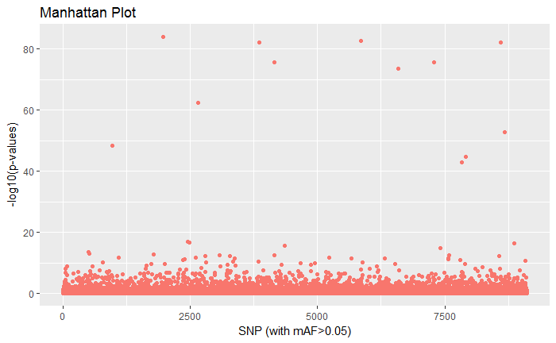

##### Questions 6:

18. What does this plot tell you?
19. The x-axis is currently order only by loci number, how could you improve it such that it provided more useful information?

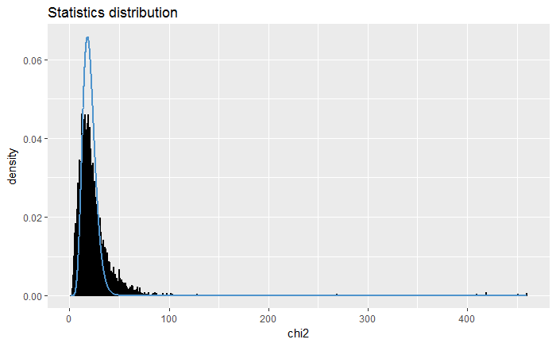

Number individuals according to which population they belong to - this will let us colour the following plot

```r
poplist<-c(rep(1,22),rep(2,22),rep(3,22),rep(4,22),rep(5,21),rep(6,22),rep(7,22),
           rep(8,22),rep(9,22),rep(10,22),rep(11,22))
print(poplist)
```

[output not shown]

Plot individuals according to their PC1 and PC2 scores, colour by popuation

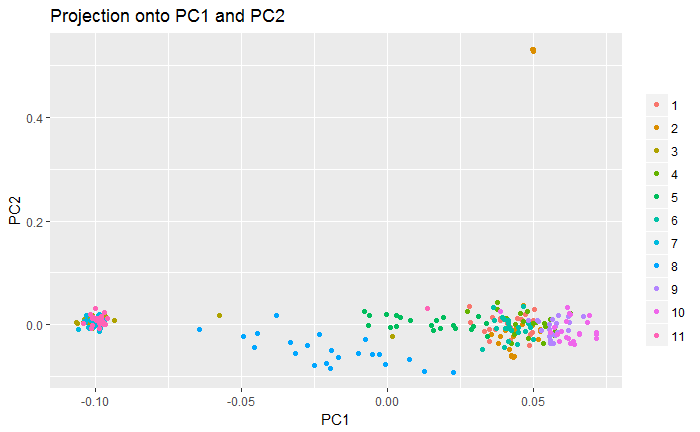

#### Now detect the outliers

use the qvalue package to convert the p-values produced by PCAdapt to q-values using the function qvalue. q-values account and are ajusted for multiple hypothesis testing

##### Questions 7:

20. Why is it important to account for multiple hypothesis testing?
21. Show the p-value and associated q-value for the first 10 indivdiuals

Set the alpha to 0.05 (pretty pedestrian)

```r
alpha <- 0.05
```

Outliers are thus loci who’s q-value is less than the alpha

```r
outliers <- which(qval<alpha)
```

##### Questions 8:

22. How many outlier loci are there?
23. Print the outliers to the screen

NICK - why are we plotting this and why is the threshold 0.01?

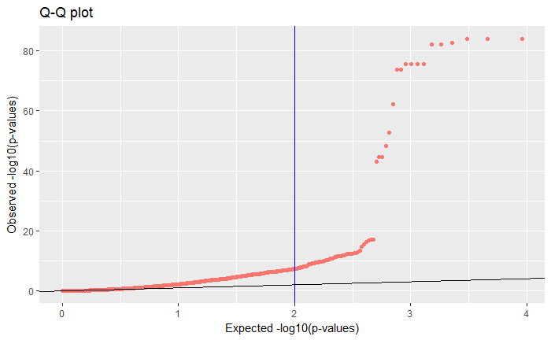

Plot a histogram of the p-values

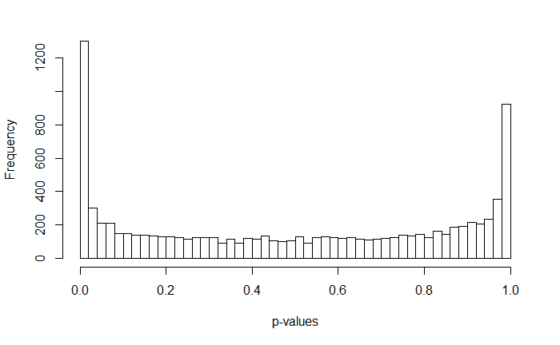

##### Questions 9:

24. Plot a histogram of the q-values
25. How do the q-values compare to the p-values and why?

### Let’s get lost in a random forest!

Since this is a random process, lets set the seed that will be used

```r
set.seed(200)
```

##### Questions 10:

26. Why do we set the seed?

Load in the ped file we loaded earlier - rename so as not to overwrite what has been done

```r
unsorted<-as.data.frame(read.table("C:/Users/JefferyN/Desktop/Postdoc/Green_Crab/RAD/PCADAPT/Crab_Example_PED.txt", sep="\t", header=F))
```

[output not shown]

This ped file needs the map file locus names transposed on top of it, so it’s essentially a square data frame

```r
unsorted[,1]
```

```
  [1] POPID  pop_1  pop_1  pop_1  pop_1  pop_1  pop_1  pop_1  pop_1  pop_1  pop_1  pop_1  pop_1  pop_1  pop_1  pop_1  pop_1  pop_1  pop_1  pop_1  pop_1  pop_1  pop_1  pop_2  pop_2  pop_2  pop_2  pop_2  pop_2  pop_2  pop_2
 [32] pop_2  pop_2  pop_2  pop_2  pop_2  pop_2  pop_2  pop_2  pop_2  pop_2  pop_2  pop_2  pop_2  pop_2  pop_3  pop_3  pop_3  pop_3  pop_3  pop_3  pop_3  pop_3  pop_3  pop_3  pop_3  pop_3  pop_3  pop_3  pop_3  pop_3  pop_3
 [63] pop_3  pop_3  pop_3  pop_3  pop_3  pop_4  pop_4  pop_4  pop_4  pop_4  pop_4  pop_4  pop_4  pop_4  pop_4  pop_4  pop_4  pop_4  pop_4  pop_4  pop_4  pop_4  pop_4  pop_4  pop_4  pop_4  pop_4  pop_5  pop_5  pop_5  pop_5
 [94] pop_5  pop_5  pop_5  pop_5  pop_5  pop_5  pop_5  pop_5  pop_5  pop_5  pop_5  pop_5  pop_5  pop_5  pop_5  pop_5  pop_5  pop_6  pop_6  pop_6  pop_6  pop_6  pop_6  pop_6  pop_6  pop_6  pop_6  pop_6  pop_6  pop_6  pop_6
[125] pop_6  pop_6  pop_6  pop_6  pop_6  pop_6  pop_6  pop_6  pop_7  pop_7  pop_7  pop_7  pop_7  pop_7  pop_7  pop_7  pop_7  pop_7  pop_7  pop_7  pop_7  pop_7  pop_7  pop_7  pop_7  pop_7  pop_7  pop_7  pop_7  pop_7  pop_8
[156] pop_8  pop_8  pop_8  pop_8  pop_8  pop_8  pop_8  pop_8  pop_8  pop_8  pop_8  pop_8  pop_8  pop_8  pop_8  pop_8  pop_8  pop_8  pop_8  pop_8  pop_8  pop_9  pop_9  pop_9  pop_9  pop_9  pop_9  pop_9  pop_9  pop_9  pop_9
[187] pop_9  pop_9  pop_9  pop_9  pop_9  pop_9  pop_9  pop_9  pop_9  pop_9  pop_9  pop_9  pop_10 pop_10 pop_10 pop_10 pop_10 pop_10 pop_10 pop_10 pop_10 pop_10 pop_10 pop_10 pop_10 pop_10 pop_10 pop_10 pop_10 pop_10 pop_10
[218] pop_10 pop_10 pop_10 pop_11 pop_11 pop_11 pop_11 pop_11 pop_11 pop_11 pop_11 pop_11 pop_11 pop_11 pop_11 pop_11 pop_11 pop_11 pop_11 pop_11 pop_11 pop_11 pop_11 pop_11 pop_11
Levels: pop_1 pop_10 pop_11 pop_2 pop_3 pop_4 pop_5 pop_6 pop_7 pop_8 pop_9 POPID
```

Data actually starts at column 7 - remove all columns before 7

Transform into a matrix

SNPs are binary, but here they have coded according to the base they represent. Convert to strictly binary (0, 1) rewriting 1-4 as 0 and 1 within each column (2) - FUNCTION

```r
change<-function(x) {
  occur<-as.data.frame(sort(table(x),decreasing=TRUE))
  x[x==as.numeric(rownames(occur)[1])]<-1
  x[x==as.numeric(rownames(occur)[2])]<-0
  x
}
rewrite<-apply(features, 2, FUN=change)
paired<-rewrite[,order(colnames(rewrite))]
#combining columns into proper single feature so 0/0=0 0/1=0.5 and 1/1=1
oddindex<-c(((1:(ncol(paired)/2))*2-1))
evenindex<-c(((1:(ncol(paired)/2))*2))
even<-paired[,evenindex]
odd<-paired[,oddindex]
new<-(odd+even)/2
colnames(new)<-substring(colnames(new),first=1, last=11)#this removes the ".1" that ends up at the end of my row/locus names
```

NICK - can you please explain the options etc. here?

```r
loci.rf<-randomForest(new, POPID, ntree=100, replace=FALSE, nodesize=10, importance=TRUE, proximity=TRUE, do.trace=10)
```

```
ntree      OOB      1      2      3      4      5      6      7      8      9     10     11     12
   10:  66.53% 90.91% 40.91% 80.95% 71.43% 40.91% 50.00% 76.19% 90.48% 68.18% 54.55% 68.18%100.00%
   20:  57.02% 77.27% 40.91% 59.09% 63.64% 45.45% 36.36% 71.43% 81.82% 54.55% 54.55% 40.91%100.00%
   30:  50.83% 86.36% 27.27% 63.64% 63.64% 36.36% 18.18% 76.19% 72.73% 50.00% 27.27% 36.36%100.00%
   40:  45.45% 81.82% 31.82% 54.55% 50.00% 22.73%  4.55% 71.43% 72.73% 27.27% 31.82% 50.00%100.00%
   50:  42.15% 81.82% 22.73% 59.09% 54.55% 36.36%  0.00% 71.43% 59.09%  9.09% 27.27% 40.91%100.00%
   60:  38.43% 90.91% 27.27% 45.45% 50.00% 13.64%  0.00% 71.43% 63.64%  4.55% 18.18% 36.36%100.00%
   70:  38.43% 77.27% 27.27% 50.00% 50.00% 13.64%  0.00% 57.14% 77.27%  9.09% 22.73% 36.36%100.00%
   80:  35.95% 72.73% 13.64% 40.91% 50.00% 22.73%  0.00% 57.14% 77.27%  0.00% 22.73% 36.36%100.00%
   90:  34.30% 68.18% 18.18% 36.36% 54.55% 18.18%  0.00% 52.38% 77.27%  0.00% 22.73% 27.27%100.00%
  100:  33.47% 59.09% 18.18% 45.45% 50.00% 13.64%  0.00% 57.14% 68.18%  4.55% 22.73% 27.27%100.00%
```

Nick - can you explain this a bit?